# Detroit Part 1

Eddie Chong

2/6/2022

Template file. Code will be included in folded blocks in the output to facilitate grading. Please knit this file and commit both the rmd and the html output. If you add external files to your analysis, please commit them to the files folder in this repository. NOTE: please do not commit large (15MB+) files to GitHub. Instead please denote the origin of the files in your code.

# Section A: Conduct an exploratory data analysis of homes in Detroit. Offer an overview of relevant trends in the data and data quality issues. Contextualize your analysis with key literature on properties in Detroit.

```
##      PARCELNO     propclass ASSESSEDVALUE  TAXABLEVALUE          year
##             0             0             0             0             0
```

```
##                  ticket_id              ticket_number
##                          0                          0
##                agency_name              violator_name
##                          0                          2
##    violation_street_number      violation_street_name
##                          0                         65
##         violation_zip_code                violator_id
##                     346751                          0
## mailing_address_str_number   mailing_address_str_name
##                          7                         21
##                       city                      state
##                       3755                       4217
##                   zip_code            non_us_str_code
##                       3758                     537635
##                    country             violation_date
##                     537623                          0
##         ticket_issued_time             violation_code
##                          0                          2
##      violation_description                disposition
##                          2                          0
##              clean_up_cost             payment_amount
##                     541391                     541391
##               payment_date             payment_status
##                     406669                     195554
##          collection_status          violation_address
##                     541391                          0
##                   parcelno
##                      32070
```

```
##      prop_addr prop_parcelnum          X2002          X2003          X2004
##              4              0         134764         132526         132976
##          X2005          X2006          X2007          X2008          X2009
##         132926         129902         132758         130899         127024
##          X2010          X2011          X2012          X2013          X2014
##         123378         122011         114970         116225         111165
##          X2015          X2016          X2017          X2018          X2019
##         110670         122420         128721         131130         132262
```

```
## parcel_num  sale_date sale_price    grantor    grantee sale_terms        ecf
##        860          0          0        123        428          1          2
## property_c
##          0
```

```
##             OBJECTID            object_id        parcel_number
##                    0                    0                    0
##                 ward              address     council_district
##                    0                    0                    0
##             zip_code           taxpayer_1           taxpayer_2
##                    0                   83               381265
##      taxpayer_street        taxpayer_city       taxpayer_state
##                  224                 1641                 1648
##         taxpayer_zip       property_class  property_class_desc
##                  229                   79                   79
##             use_code        use_code_desc           tax_status
##                 5666                32910                   79
## total_square_footage        total_acreage             frontage
##                   79                   79                   79
##                depth        homestead_pre                  nez
##                   79                   79               305079
##          is_improved            num_bldgs     total_floor_area
##                   79                    0               143664
##                style           year_built           sale_price
##               143995               143664                    0
##            sale_date       assessed_value        taxable_value
##               100182                    0                    0
##              landmap              related               zoning
##                    0                    0                    0
##          subdivision         SHAPE_Length           SHAPE_Area
##                    0                    0                    0
##                    X                    Y
##                    0                    0
```

```
##      PARCELNO      PROPADDR       ZIPCODE     TAXPAYER1      TAXPADDR
##             0             0        387716           763           792
##      TAXPCITY     TAXPSTATE       TAXPZIP     propclass     TAXSTATUS
##           918           947           771           763           763
##     TOTALSQFT  TOTALACREAGE      FRONTAGE           PRE     SALEPRICE
##           763           763           763        387716           763
##      SALEDATE ASSESSEDVALUE  TAXABLEVALUE   RESBLDCOUNT      tax_year
##         92600           763           763           763             0
```

```
##    Min. 1st Qu.  Median    Mean 3rd Qu.    Max.
##       0     400    9900   12588   17443 1736600
```

```
##    Min. 1st Qu.  Median    Mean 3rd Qu.    Max.
##       0     318    7882    9842   14168 1392600
```

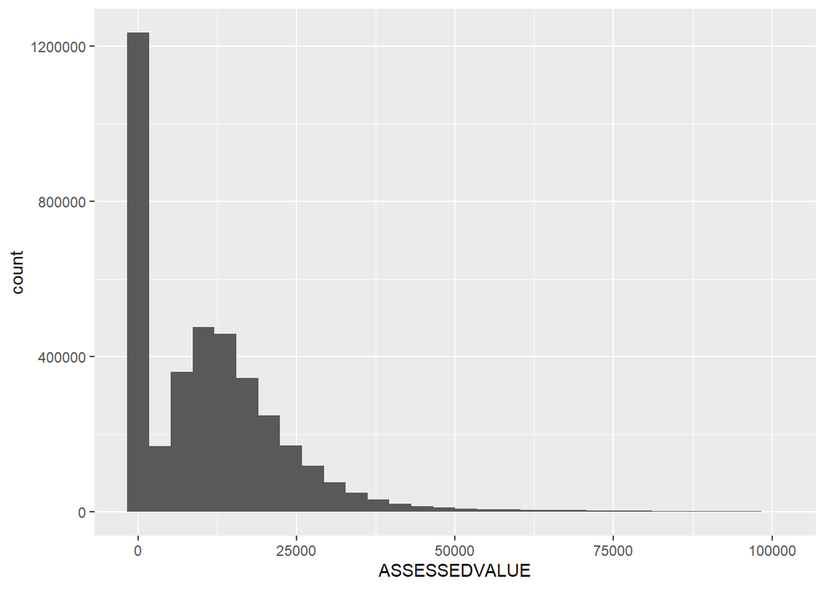

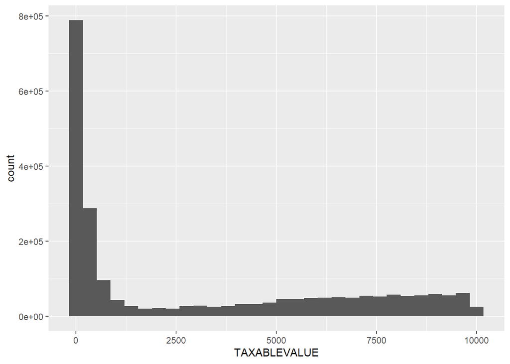

When looking at the current state of housing in Detroit, it is the outcome of deindustrialization that displaced residents, governmental mismanagement, and structural inequality that put more burden on marginalized residents. However, the people who still reside in Detroit face challenges in terms of the inequities between how homes are assessed and taxed.

In terms of general data quality, the assessments dataset is very robust with no missing values. Sales data is also relatively low in the amount of missing values that potentially can be addressed in data cleaning. The foreclosure dataset is of concern since it is organized in a manner that makes analysis difficult since it is essentially dichotomous variable over the years.

When looking at the general distribution of assessed and taxable value of properties, the majority of property are skewed lower, if not at zero.

References: Presbey, G. M. (2015). Globalization and the Crisis in Detroit. Perspectives on Global Development and Technology, 14(1-2), 261-277.

Tabb, W. K. (2015). If Detroit is dead, some things need to be said at the funeral. Journal of Urban Affairs, 37(1), 1-12.